# Allgemeine_Aufgaben_Gruppe_08

Brayan Orjuela Pico, Chen Xue, Tobias Königer, Xin Zhou, Yue Zhang

# 1 Vorbearbeitung

## 1.1 Laden aller Packages

```r
if(!require(pacman)) {
  install.packages("pacman")
  require(pacman)
}

if(!require(janitor)) {
  install.packages("janitor")
  require(janitor)
}

p_load(tidyverse,
       data.table,
       janitor,
       fitdistrplus,
       lubridate   # für  Bearbeitung von  Zeit und  Datum
       )
```

## 1.2 Code für Aufgabe 1

### 1.2.1 Importieren des Rohdatensatzes

```r
# Komponente_K7.csv importieren
# und benennen als  Ausliefergung_K7_roh
Ausliefergung_K7_roh <- fread("./Data/Logistikverzug/Komponente_K7.csv")

# Logistikverzug_K7.csv importieren
# und benennen als  Eingang_K7_roh
Eingang_K7_roh<- fread("./Data/Logistikverzug/Logistikverzug_K7.csv")
```

### 1.2.2 Information des Rohdatensatzes

- Produkte kommen aus verschiedene Werkstatt von Lieferanten
- `IDNummer` ist Primary-key und beinhalten Information von Werkstatt
- `Produktionsdatum` ist die Auslieferungsdatum, aber in Format von `character`

```r
#summary Ausliefergung_K7_roh
summary(Ausliefergung_K7_roh)
```

```
##        V1           IDNummer         Produktionsdatum   Herstellernummer
##  Min.   :     1   Length:306490      Length:306490      Min.   :112
##  1st Qu.: 76623   Class :character   Class :character   1st Qu.:112
##  Median :153246   Mode  :character   Mode  :character   Median :113
##  Mean   :153246                                         Mean   :113
##  3rd Qu.:229868                                         3rd Qu.:114
##  Max.   :306490                                         Max.   :114
##   Werksnummer     Fehlerhaft
##  Min.   :1132   Min.   :0.00e+00
##  1st Qu.:1132   1st Qu.:0.00e+00
##  Median :1137   Median :0.00e+00
##  Mean   :1137   Mean   :1.96e-05
##  3rd Qu.:1142   3rd Qu.:0.00e+00
##  Max.   :1142   Max.   :1.00e+00
```

```r
str(Ausliefergung_K7_roh)
```

```
## Classes 'data.table' and 'data.frame':   306490 obs. of  6 variables:
##  $ V1              : int  1 2 3 4 5 6 7 8 9 10 ...
##  $ IDNummer        : chr  "K7-114-1142-1" "K7-114-1142-2" "K7-114-1142-3" "K7-114-1142-4" ...
##  $ Produktionsdatum: chr  "2008-11-12" "2008-11-12" "2008-11-13" "2008-11-13" ...
##  $ Herstellernummer: int  114 114 114 114 114 114 114 114 114 114 ...
##  $ Werksnummer     : int  1142 1142 1142 1142 1142 1142 1142 1142 1142 1142 ...
##  $ Fehlerhaft      : int  0 0 0 0 0 0 0 0 0 0 ...
##  - attr(*, ".internal.selfref")=<externalptr>
```

- Produkte kommen aus verschiedene Werkstatt von Lieferanten
- `IDNummer` ist Primary-key und beinhalten Information von Werkstatt
- `Wareneingang` ist die Eingangsdatum, aber in Format von `character`

```r
#summary  Eingang_K7_roh
summary(Eingang_K7_roh)
```

```
##        V1           IDNummer         Wareneingang       Herstellernummer
##  Min.   :     1   Length:306490      Length:306490      Min.   :112
##  1st Qu.: 76623   Class :character   Class :character   1st Qu.:112
##  Median :153246   Mode  :character   Mode  :character   Median :113
##  Mean   :153246                                         Mean   :113
##  3rd Qu.:229868                                         3rd Qu.:114
##  Max.   :306490                                         Max.   :114
##   Werksnummer     Fehlerhaft
##  Min.   :1132   Min.   :0
##  1st Qu.:1132   1st Qu.:0
##  Median :1137   Median :0
##  Mean   :1137   Mean   :0
##  3rd Qu.:1142   3rd Qu.:0
##  Max.   :1142   Max.   :0
```

```r
str(Eingang_K7_roh)
```

```
## Classes 'data.table' and 'data.frame':   306490 obs. of  6 variables:
##  $ V1              : int  1 2 3 4 5 6 7 8 9 10 ...
##  $ IDNummer        : chr  "K7-113-1132-153160" "K7-113-1132-153109" "K7-113-1132-153195" "K7-113-1132-153226" ...
##  $ Wareneingang    : chr  "2016-11-22" "2016-11-20" "2016-11-20" "2016-11-20" ...
##  $ Herstellernummer: int  112 112 112 112 112 112 112 112 112 112 ...
##  $ Werksnummer     : int  1132 1132 1132 1132 1132 1132 1132 1132 1132 1132 ...
##  $ Fehlerhaft      : int  0 0 0 0 0 0 0 0 0 0 ...
##  - attr(*, ".internal.selfref")=<externalptr>
```

### 1.2.3 Aufbreitung des Rohdatensatzes

> Sie können davon ausgehen, dass der Hersteller das Teil am Produktionstag in den Warenausgang übergibt.

Deswegen `Produktionsdatum` ist das Auslieferungsdatum.

Die Formel zur Berechnung des Logistikverzugs lautet:

$$Logistikverzug=Eingangsdatum -Auslieferungsdatum$$
Die Berechung ist nur sinnvoll,wenn `Eingangsdatum` und `Auslieferungsdatum` gleichzeitig vorhanden (kein `NA`) sein.Deswegen nur gemeinsame Einträge in beide Tabelle werden berücksichtigt.Dementsprechend ist die Funktion `inner_join()` zu verwenden.

Und der Logistikverzug sollen auf bestimme Werkstatt beziehen.

```r
Logistik<-dplyr::inner_join(Ausliefergung_K7_roh,Eingang_K7_roh,by="IDNummer")%>%
  dplyr::select(IDNummer,Produktionsdatum,Wareneingang)%>%
  dplyr::rename(Auslieferungsdatum=Produktionsdatum,Eingangsdatum=Wareneingang)%>%
  dplyr::mutate(Auslieferungsdatum=as_date(Auslieferungsdatum),
                Eingangsdatum=as_date(Eingangsdatum))%>%
  dplyr::mutate(Werkstatt=str_sub(IDNummer,8,11))

#Alle Produkte kommen aus zwei Werkstatt 1132 und 1142
table(Logistik$Werkstatt)
```

```
##
##   1132   1142
## 153245 153245
```

### 1.2.4 Ermittlung des Logistikverzug

```r
Logistik_mit_Verzug<-Logistik%>%
  dplyr::mutate(Logistikverzug=time_length(interval(Auslieferungsdatum,Eingangsdatum),unit = "day"))%>%
  dplyr::mutate(Logistikverzug=as.integer(Logistikverzug))

#Logistikverzug aus Werkstatt 1132
Verzug_1132<-Logistik_mit_Verzug%>%
  dplyr::filter(Werkstatt=="1132")

#Logistikverzug aus Werkstatt 1142
Verzug_1142<-Logistik_mit_Verzug%>%
  dplyr::filter(Werkstatt=="1142")
```

### 1.2.5 Test der Wahrscheilichkeitsverteilung

#### 1.2.5.1 Vermutung der Verteilgung aus Daten

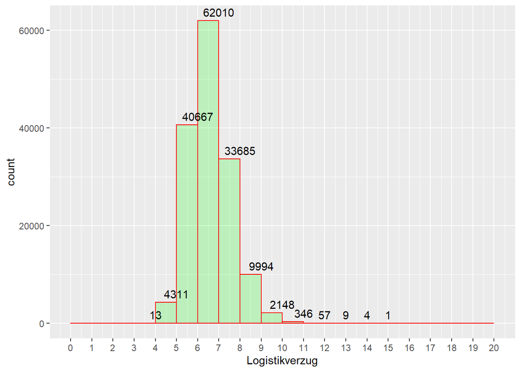

```r
#Beobachtung der Verteilung der Logistikverzugstag aus dem Werk 1132
ggplot(Verzug_1132,aes(x=Logistikverzug))+
  geom_histogram(breaks=seq(0, 20, by = 1),
                 col="red",
                 fill="green",
                 alpha = .2) +

  scale_x_continuous(breaks = seq(0, 20, 1)) +
  geom_text(aes(label=as.character(..count..)),stat="bin", binwidth = 1, vjust=-0.5)
```

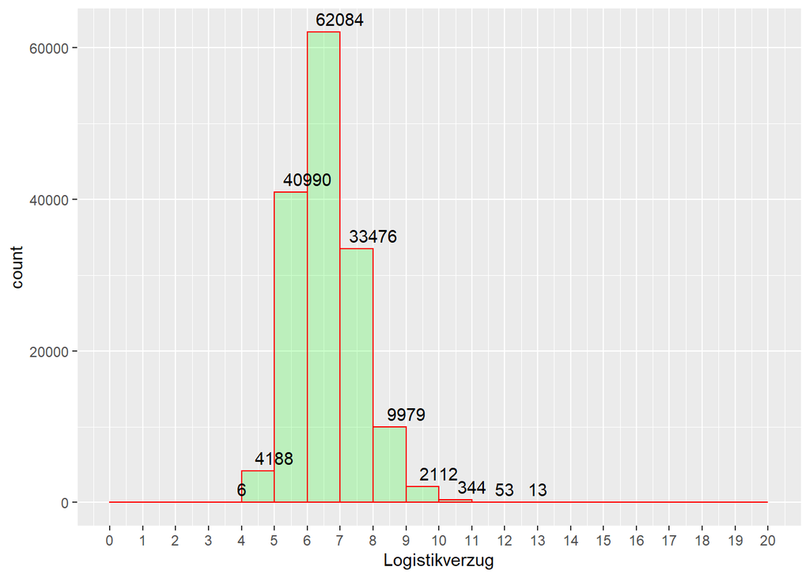

```r
#Beobachtung der Verteilung der Logistikverzugstag aus dem Werk 1132
ggplot(Verzug_1142,aes(x=Logistikverzug))+
  geom_histogram(breaks=seq(0, 20, by = 1),
                 col="red",
                 fill="green",
                 alpha = .2) +

  scale_x_continuous(breaks = seq(0, 20, 1)) +
  geom_text(aes(label=as.character(..count..)),stat="bin", binwidth = 1, vjust=-0.5)
```

Um es entscheiden, welche Verteilungsmodell zu testen, verwenden wir die Funktion `fitdistrplus::descdist ()` aus der Package [fitdistrplus](https://cran.r-project.org/web/packages/fitdistrplus/vignettes/paper2JSS.pdf)

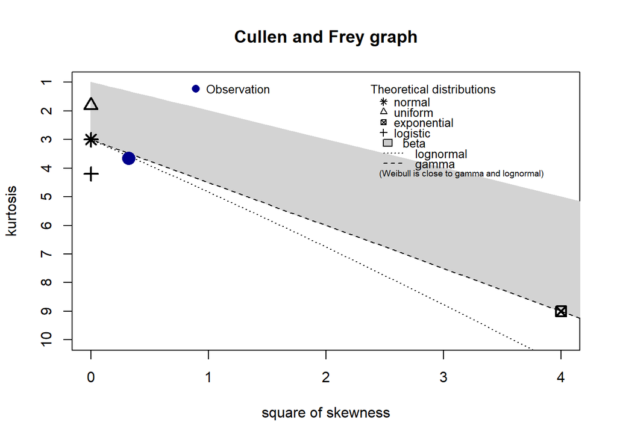

```
## summary statistics
## ------
## min:  4   max:  15
## median:  7
## mean:  7.081882
## estimated sd:  1.013915
## estimated skewness:  0.5662176
## estimated kurtosis:  3.654663
```

```r
delayTime_1132 <- Verzug_1132$Logistikverzug
# mögliche Modell für Logistikverzug aus Werkstatt 1132
descdist(delayTime_1132, discrete = FALSE, boot = NULL, method = "unbiased",
         graph = TRUE,
         obs.col = "darkblue",
         obs.pch = 16,
         boot.col = "orange")
```

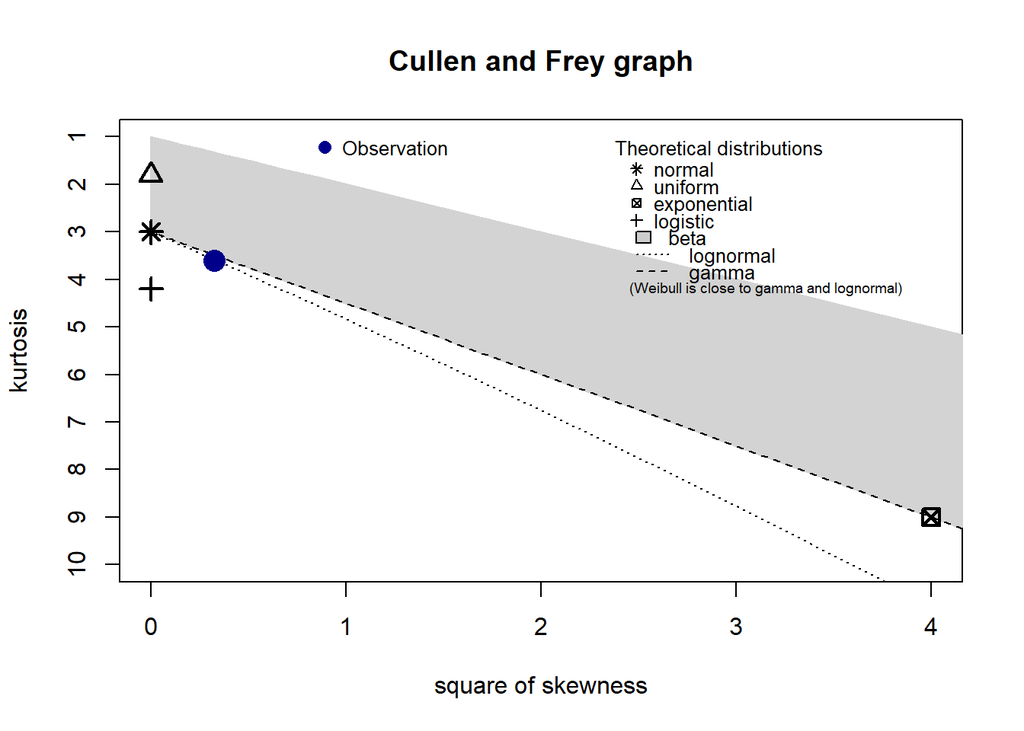

```
## summary statistics
## ------
## min:  4   max:  13
## median:  7
## mean:  7.078991
## estimated sd:  1.010687
## estimated skewness:  0.5685846
## estimated kurtosis:  3.605104
```

```r
delayTime_1142 <- Verzug_1142$Logistikverzug
# mögliche Modell für Logistikverzug aus Werkstatt 1142
descdist(delayTime_1142, discrete = FALSE, boot = NULL, method = "unbiased",
         graph = TRUE,
         obs.col = "darkblue",
         obs.pch = 16,
         boot.col = "orange")
```

Gemäß dem beidem Diagramm sind die Verteilungen dem Observationspunkt am nächsten liegen, lognormal, gamma, und die Weibull-Verteilung. Deswegen untersuchen wir die lognormal, gamma, und die Weibull-Verteilung

#### 1.2.5.2 Einschätzung der Parameter für bestimmt Verteilungsmodell

Anpassung für Logistikverzug aus Wertstatt 1132

```r
## Anpassung der lognormalverteilung
lognormal_fit_1132 <- fitdistr(delayTime_1132, densfun = "lognormal")
lognormal_fit_1132
```

```
##      meanlog         sdlog
##   1.9475111302   0.1412246992
##  (0.0003607593) (0.0002550953)
```

```r
## Anpassung der Gammaverteilung
gamma_fit_1132 <- fitdistr(delayTime_1132, densfun = "gamma")
gamma_fit_1132
```

```
##       shape         rate
##   50.02530975    7.06384631
##  ( 0.18011709) ( 0.02556113)
```

```r
## Anpassung der Weibullverteilung
weibull_fit_1132 <- fitdistr(delayTime_1132, densfun = "weibull", lower = 0)
weibull_fit_1132
```

```
##       shape         scale
##   6.846337576   7.529041871
##  (0.012112677) (0.002980729)
```

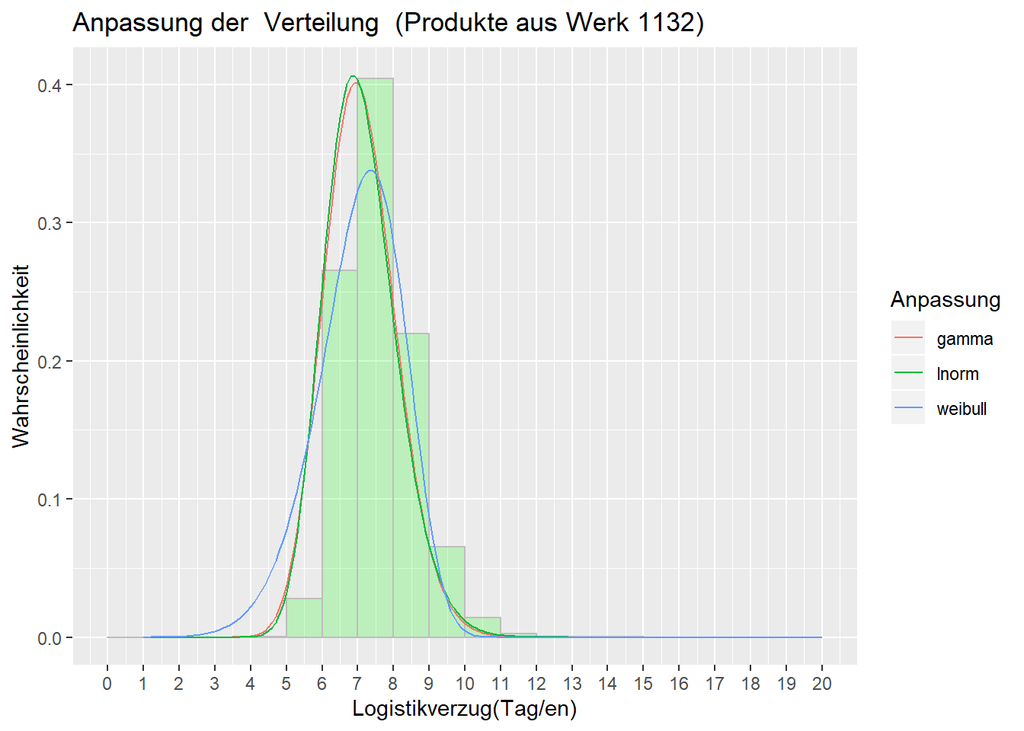

```r
xs <- seq(1, 20, 0.1)

# Berechnung der Wahrscheinlichkeitsdichte
den_gamma_1132 <- dgamma(xs,
                         shape = gamma_fit_1132$estimate["shape"],
                         rate = gamma_fit_1132$estimate["rate"])
den_lnorm_1132 <-  dlnorm(xs,
                          meanlog = lognormal_fit_1132$estimate["meanlog"],
                          lognormal_fit_1132$estimate["sdlog"])
den_weibull_1132 <- dweibull(xs,
                             shape = weibull_fit_1132$estimate["shape"],
                             weibull_fit_1132$estimate["scale"])


dat_1132 <- data.frame(x=xs, lnorm=den_lnorm_1132, gamma = den_gamma_1132, weibull = den_weibull_1132)%>%
  gather(key = "Anpassung", value = "den", lnorm, gamma, weibull)




Darstellung_1132<-ggplot(Verzug_1132,aes(x=Logistikverzug))+
    geom_histogram(aes(y=..density..), breaks=seq(0, 20, by = 1),
                   col="gray",
                   closed = "left",
                   fill="green",
                   alpha = .2) +
    scale_x_continuous(breaks = seq(0, 20, 1)) +
    geom_line(data = dat_1132, aes(x=x, y=den, group = Anpassung, color = Anpassung)) +
    ggtitle("Anpassung der  Verteilung  (Produkte aus Werk 1132)") +
    xlab("Logistikverzug(Tag/en)") +
    ylab("Wahrscheinlichkeit")

Darstellung_1132
```

Anpassung für Logistikverzug aus Wertstatt 1142

```r
## Anpassung der lognormalverteilung
lognormal_fit_1142 <- fitdistr(delayTime_1142, densfun = "lognormal")
lognormal_fit_1142
```

```
##      meanlog         sdlog
##   1.9471644704   0.1407599105
##  (0.0003595720) (0.0002542558)
```

```r
## Anpassung der Gammaverteilung
gamma_fit_1142 <- fitdistr(delayTime_1142, densfun = "gamma")
gamma_fit_1142
```

```
##       shape         rate
##   50.33356725    7.11027633
##  ( 0.18123073) ( 0.02572889)
```

```r
## Anpassung der Weibullverteilung
weibull_fit_1142 <- fitdistr(delayTime_1142, densfun = "weibull", lower = 0)
weibull_fit_1142
```

```
##       shape         scale
##   6.878156739   7.525435739
##  (0.012221448) (0.002966066)
```

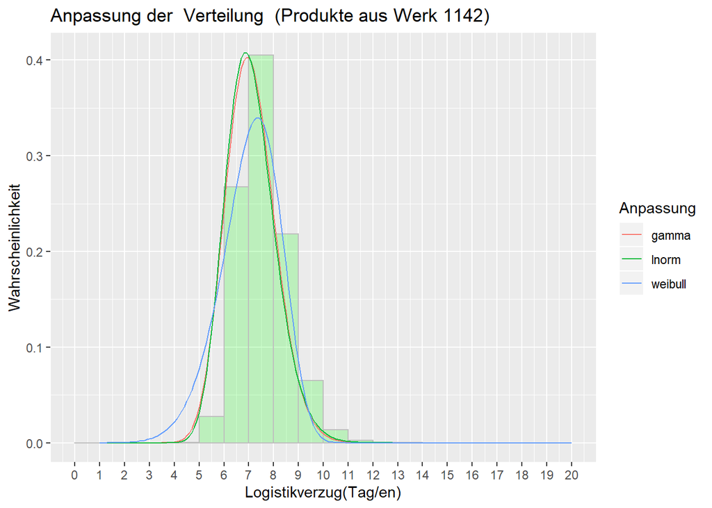

```r
xs <- seq(1, 20, 0.1)

# Berechnung der Wahrscheinlichkeitsdichte
den_gamma_1142 <- dgamma(xs,
                    shape = gamma_fit_1142$estimate["shape"],
                    rate = gamma_fit_1142$estimate["rate"])
den_lnorm_1142 <-  dlnorm(xs,
                     meanlog = lognormal_fit_1142$estimate["meanlog"],
                     lognormal_fit_1142$estimate["sdlog"])
den_weibull_1142 <- dweibull(xs,
                        shape = weibull_fit_1142$estimate["shape"],
                        weibull_fit_1142$estimate["scale"])


dat_1142 <- data.frame(x=xs, lnorm=den_lnorm_1142, gamma = den_gamma_1142, weibull = den_weibull_1142)%>%
  gather(key = "Anpassung", value = "den", lnorm, gamma, weibull)




Darstellung_1142<-ggplot(Verzug_1142,aes(x=Logistikverzug))+
    geom_histogram(aes(y=..density..), breaks=seq(0, 20, by = 1),
                   col="gray",
                   closed = "left",
                   fill="green",
                   alpha = .2) +
    scale_x_continuous(breaks = seq(0, 20, 1)) +
    geom_line(data = dat_1142, aes(x=x, y=den, group =Anpassung, color = Anpassung))+
    ggtitle( "Anpassung der  Verteilung  (Produkte aus Werk 1142)") +
    xlab("Logistikverzug(Tag/en)") +
    ylab("Wahrscheinlichkeit")
Darstellung_1142
```

#### 1.2.5.3 Auswertung die Anpassungsqualität

Wie in der Abbildung gezeigt, passen die Lognormalverteilungen und Gammaverteilungen besser zu den Daten. Der Chi-Quadrat-Test wurde verwendet, um die Anpassung der beiden Verteilungen zu testen.

```r
# Fit-Test für Lognorm- und Gamma-Verteilungen
# bezogen auf Werkstatt 1132

day_sn_1132 <- seq(min(delayTime_1132), max(delayTime_1132))


# Berechnung der theoretischen Tage unter Lognormverteilung
day_lognorm_dist_1132 <- sapply(day_sn_1132, function(x) {
    p <-plnorm(x+1,
                meanlog = lognormal_fit_1132$estimate["meanlog"],
                lognormal_fit_1132$estimate["sdlog"]) -
        plnorm(x,
               meanlog = lognormal_fit_1132$estimate["meanlog"],
               lognormal_fit_1132$estimate["sdlog"])

    round(p * length(delayTime_1132))
})

names(day_lognorm_dist_1132) <- as.character(day_sn_1132)


# Berechnung der theoretischen Tage unter Gammaverteilung
day_gamma_dist_1132 <- sapply(day_sn_1132, function(x) {
    p <-pgamma(x+1,
               shape = gamma_fit_1132$estimate["shape"],
               rate = gamma_fit_1132$estimate["rate"]) -
        pgamma(x,
               shape = gamma_fit_1132$estimate["shape"],
               rate = gamma_fit_1132$estimate["rate"])

    round(p * length(delayTime_1132))
})

names(day_gamma_dist_1132) <- as.character(day_sn_1132)


day_1132 <- table(Verzug_1132$Logistikverzug)

day_1132
```

```
##
##     4     5     6     7     8     9    10    11    12    13    14    15
##    13  4311 40667 62010 33685  9994  2148   346    57     9     4     1
```

```r
day_lognorm_dist_1132
```

```
##     4     5     6     7     8     9    10    11    12    13    14    15
##  1272 19417 55235 50482 20932  4988   805    98    10     1     0     0
```

```r
day_gamma_dist_1132
```

```
##     4     5     6     7     8     9    10    11    12    13    14    15
##  1717 19279 53473 51626 21766  4718   594    48     3     0     0     0
```

```r
chisq.test(day_1132, day_lognorm_dist_1132)
```

```
##
##  Pearson's Chi-squared test
##
## data:  day_1132 and day_lognorm_dist_1132
## X-squared = 120, df = 110, p-value = 0.2421
```

```r
chisq.test(day_1132, day_gamma_dist_1132)
```

```
##
##  Pearson's Chi-squared test
##
## data:  day_1132 and day_gamma_dist_1132
## X-squared = 108, df = 99, p-value = 0.252
```

Aus den Testergebnissen können wir erkennen, dass der p-value nicht signifikant und der Unterschiede nicht groß sind, was darauf hinweist, dass beide Verteilungen zu den Daten passen können und die Gammaverteilung etwas besser als die Lognormalverteilung ist.

```r
# Fit-Test für Lognorm- und Gamma-Verteilungen
# bezogen auf Werkstatt 1142

day_sn_1142 <- seq(min(delayTime_1142), max(delayTime_1142))


# Berechnung der theoretischen Tage unter Lognormverteilung
day_lognorm_dist_1142 <- sapply(day_sn_1142, function(x) {
    p <-plnorm(x+1,
                meanlog = lognormal_fit_1142$estimate["meanlog"],
                lognormal_fit_1142$estimate["sdlog"]) -
        plnorm(x,
               meanlog = lognormal_fit_1142$estimate["meanlog"],
               lognormal_fit_1142$estimate["sdlog"])

    round(p * length(delayTime_1142))
})

names(day_lognorm_dist_1142) <- as.character(day_sn_1142)


# Berechnung der theoretischen Tage unter Gammaverteilung
day_gamma_dist_1142 <- sapply(day_sn_1142, function(x) {
    p <-pgamma(x+1,
               shape = gamma_fit_1142$estimate["shape"],
               rate = gamma_fit_1142$estimate["rate"]) -
        pgamma(x,
               shape = gamma_fit_1142$estimate["shape"],
               rate = gamma_fit_1142$estimate["rate"])

    round(p * length(delayTime_1142))
})

names(day_gamma_dist_1142) <- as.character(day_sn_1142)


day_1142 <- table(Verzug_1142$Logistikverzug)

day_1142
```

```
##
##     4     5     6     7     8     9    10    11    12    13
##     6  4188 40990 62084 33476  9979  2112   344    53    13
```

```r
day_lognorm_dist_1142
```

```
##     4     5     6     7     8     9    10    11    12    13
##  1253 19397 55422 50552 20819  4910   782    94     9     1
```

```r
day_gamma_dist_1142
```

```
##     4     5     6     7     8     9    10    11    12    13
##  1697 19269 53655 51696 21644  4640   576    45     2     0
```

```r
chisq.test(day_1142, day_lognorm_dist_1142)
```

```
##
##  Pearson's Chi-squared test
##
## data:  day_1142 and day_lognorm_dist_1142
## X-squared = 90, df = 81, p-value = 0.2313
```

```r
chisq.test(day_1142, day_gamma_dist_1142)
```

```
##
##  Pearson's Chi-squared test
##
## data:  day_1142 and day_gamma_dist_1142
## X-squared = 90, df = 81, p-value = 0.2313
```

Aus den Testergebnissen können wir erkennen, dass die p-values nicht signifikant sind, sondern fast gleich, was darauf hinweist, dass beide Verteilungen(Lognorm- und Gamma-Verteilungen ) zu den Daten passen können.

### 1.2.6 Code für Aufgabe 1b

```r
Min_Verzug<-min(Logistik_mit_Verzug$Logistikverzug)
Min_Verzug
```

```
## [1] 4
```

```r
Max_Verzug<-max(Logistik_mit_Verzug$Logistikverzug)
Max_Verzug
```

```
## [1] 15
```

### 1.2.7 Code für Aufgabe 1c

```r
Mittel_Verzug<-mean(Logistik_mit_Verzug$Logistikverzug)
Mittel_Verzug
```

```
## [1] 7.080437
```

## 1.3 Code für Aufgabe 3

### 1.3.1 Ermittlung K7-Fahrzeug-Beziehung

wir weiß nicht, mit wie viele K7_Komponent ein Fahrzeug ausrüsten darf. Deswegen betrachten wir alle Komponente von aller Fahrzeuge. Damit hat jede K7 eine eindeutige(einzige) Abbildung auf ein Fahrzeug.

```r
#aller Komponent-Fahrzeug-Beziehung importieren
Bestandteile_Fahrzeuge_OEM1_Typ11 <- read_delim("./Data/Fahrzeug/Bestandteile_Fahrzeuge_OEM1_Typ11.csv",
                                                ";", escape_double = FALSE, trim_ws = TRUE)
Bestandteile_Fahrzeuge_OEM1_Typ12 <- read_delim("./Data/Fahrzeug/Bestandteile_Fahrzeuge_OEM1_Typ12.csv",
                                                ";", escape_double = FALSE, trim_ws = TRUE)
Bestandteile_Fahrzeuge_OEM2_Typ21 <- read_delim("./Data/Fahrzeug/Bestandteile_Fahrzeuge_OEM2_Typ21.csv",
                                                ";", escape_double = FALSE, trim_ws = TRUE)
Bestandteile_Fahrzeuge_OEM2_Typ22 <- read_delim("./Data/Fahrzeug/Bestandteile_Fahrzeuge_OEM2_Typ22.csv",
                                                ";", escape_double = FALSE, trim_ws = TRUE)

#aller Komponent-Fahrzeug-Beziehung in eine Tabelle zusammensetzen

Bestandteile_alle_Fahrzeuge<-dplyr::bind_rows(
  Bestandteile_Fahrzeuge_OEM1_Typ11,
  Bestandteile_Fahrzeuge_OEM1_Typ12,
  Bestandteile_Fahrzeuge_OEM2_Typ21,
  Bestandteile_Fahrzeuge_OEM2_Typ22
)
str(Bestandteile_alle_Fahrzeuge)
```

```
## Classes 'spec_tbl_df', 'tbl_df', 'tbl' and 'data.frame': 3204104 obs. of  6 variables:
##  $ X1           : num  1 2 3 4 5 6 7 8 9 10 ...
##  $ ID_Karosserie: chr  "K4-112-1121-3" "K4-112-1121-4" "K4-112-1121-7" "K4-112-1121-9" ...
##  $ ID_Schaltung : chr  "K3SG1-105-1051-32" "K3SG1-105-1051-141" "K3SG1-105-1051-106" "K3SG1-105-1051-21" ...
##  $ ID_Sitze     : chr  "K2LE1-109-1091-2" "K2ST1-109-1092-5" "K2ST1-109-1092-57" "K2ST1-109-1092-91" ...
##  $ ID_Motor     : chr  "K1BE1-101-1011-7" "K1BE1-101-1011-12" "K1BE1-101-1011-38" "K1BE1-101-1011-97" ...
##  $ ID_Fahrzeug  : chr  "11-1-11-1" "11-1-11-2" "11-1-11-3" "11-1-11-4" ...
```

```r
# Komponent-Fahrzeug-Beziehung anpassen

Komponent_Fahrzeug_Beziehung<-Bestandteile_alle_Fahrzeuge%>%
  tidyr::gather("ID_Karosserie","ID_Schaltung","ID_Sitze","ID_Motor",key="ID_Typ",value="ID_Komponent")


str(Komponent_Fahrzeug_Beziehung)
```

```
## Classes 'tbl_df', 'tbl' and 'data.frame':    12816416 obs. of  4 variables:
##  $ X1          : num  1 2 3 4 5 6 7 8 9 10 ...
##  $ ID_Fahrzeug : chr  "11-1-11-1" "11-1-11-2" "11-1-11-3" "11-1-11-4" ...
##  $ ID_Typ      : chr  "ID_Karosserie" "ID_Karosserie" "ID_Karosserie" "ID_Karosserie" ...
##  $ ID_Komponent: chr  "K4-112-1121-3" "K4-112-1121-4" "K4-112-1121-7" "K4-112-1121-9" ...
```

```r
# Fahrzeug mit Komponent-K7 herausfinden
K7_Fahrzeug_Beziehung<-Komponent_Fahrzeug_Beziehung%>%
  dplyr::select(ID_Fahrzeug,ID_Komponent)%>%
  tidyr::separate(ID_Komponent,
                  into=c("Komponent_Benennung","Hersteller","Werk","Serien"),
                  sep="-",
                  remove = FALSE)%>%
  dplyr::select(ID_Fahrzeug,ID_Komponent,Komponent_Benennung)%>%
  dplyr::filter(Komponent_Benennung=="K7")%>%
  dplyr::rename(ID_K7=ID_Komponent)%>%
  dplyr::select(ID_Fahrzeug,ID_K7)


# Anzahl der Fahrzeug mit Komponent-K7
# ist gleich wie
# Anzahl der ausgelieferten Komponent-K7
nrow(K7_Fahrzeug_Beziehung)==nrow(Ausliefergung_K7_roh)
```

```
## [1] TRUE
```

### 1.3.2 Ermittlung aller in-Köln-zugelassenen Fahrzeuge

```r
#aller Zugelassene Fahrzeug importieren
Zulassungen_alle_Fahrzeuge <- read_delim("./Data/Zulassungen/Zulassungen_alle_Fahrzeuge.csv",
                                                ";", escape_double = FALSE, trim_ws = TRUE)

str(Zulassungen_alle_Fahrzeuge)
```

```
## Classes 'spec_tbl_df', 'tbl_df', 'tbl' and 'data.frame': 3204104 obs. of  4 variables:
##  $ X1       : num  408097 408098 1 2 3 ...
##  $ IDNummer : chr  "11-1-11-1" "11-1-11-2" "12-1-12-1" "12-1-12-2" ...
##  $ Gemeinden: chr  "DRESDEN" "DRESDEN" "LEIPZIG" "LEIPZIG" ...
##  $ Zulassung: Date, format: "2009-01-01" "2009-01-01" ...
##  - attr(*, "spec")=
##   .. cols(
##   ..   X1 = col_double(),
##   ..   IDNummer = col_character(),
##   ..   Gemeinden = col_character(),
##   ..   Zulassung = col_date(format = "")
##   .. )
```

```r
# Beziehung von Fahrzeug  und Gemeinde herausfinden

Gemeinde_Fahrzeug_Beziehung<-Zulassungen_alle_Fahrzeuge%>%
  dplyr::select(Gemeinden,IDNummer)%>%
  dplyr::rename(ID_Fahrzeug=IDNummer)

str(Gemeinde_Fahrzeug_Beziehung)
```

```
## Classes 'spec_tbl_df', 'tbl_df', 'tbl' and 'data.frame': 3204104 obs. of  2 variables:
##  $ Gemeinden  : chr  "DRESDEN" "DRESDEN" "LEIPZIG" "LEIPZIG" ...
##  $ ID_Fahrzeug: chr  "11-1-11-1" "11-1-11-2" "12-1-12-1" "12-1-12-2" ...
##  - attr(*, "spec")=
##   .. cols(
##   ..   X1 = col_double(),
##   ..   IDNummer = col_character(),
##   ..   Gemeinden = col_character(),
##   ..   Zulassung = col_date(format = "")
##   .. )
```

```r
# in-Köln-zugelassenen Fahrzeugee herausfinden
# wir sind keine Deutsche, wir weiß nicht die genaue die erkundliche Unterteilung in Deutschland.
# wir berücksichtigen nur die Gemeinde, die wortgenau als "KOELN" lautet

KOELN_Fahrzeug<-Gemeinde_Fahrzeug_Beziehung%>%
  dplyr::filter(Gemeinden=="KOELN")
```

### 1.3.3 Anzahl der Bedingung-erfüllte Komponenten K7

Bedingung-erfüllte KomponentenK7 muss zuerst in Fahrzeug ausgerüstet, und das Fahrzeug muss gleichzeitig in-Köln-zugelassenen. Deswegen verwenden wir `inner_join()`

```r
#in diesem Tabelle ist die Anzahl von Einträgen genau wie die gesuchte Anzahl von K7,dieandeten in Fahrzeugen, die in Köln zugelassen wurden
K7_In_KOELN<-inner_join(K7_Fahrzeug_Beziehung,KOELN_Fahrzeug,by="ID_Fahrzeug")
```

## 1.4 Code für Aufgabe 4

Der Datensatz `Zulassungen_alle_Fahrzeuge` wurde schon bei Bearbeitung von Aufgabe 3 importiert.

## 1.5 Code für Aufgabe 6

Die Beziehung zwischen Komponent und Fahrzeug `Komponent_Fahrzeug_Beziehung` und die Beziehung zwischen Gemeinden und Fahrzeug `Gemeinde_Fahrzeug_Beziehung` wurden schon bei Aufgabe 3 gekriegt.

```r
# die Fahrzeug herausfinden
ID_Unfall<-Komponent_Fahrzeug_Beziehung[
  which(Komponent_Fahrzeug_Beziehung$ID_Komponent=="K4-112-1121-23"),]$ID_Fahrzeug

# den Zulassungsort herausfinden
Ort_Zulassung<-Gemeinde_Fahrzeug_Beziehung[
  which(Gemeinde_Fahrzeug_Beziehung$ID_Fahrzeug==ID_Unfall),]$Gemeinden

Ort_Zulassung
```

```
## [1] "RADEBERG"
```

# 2 Aufgabe 1

> Logistik spielt in der Produktentwicklung der Automobilindustrie eine immer größer werdende Rolle. So müssen vom Lieferanten produzierte Teile zunächst zum OEM geliefert werden, bevor sie eingebaut werden können. Was auf den ersten Blick logisch erscheint, sollte für eine professionelle Organisation unbedingt näher analysiert werden. Erstellen Sie deshalb eine Verteilung für den Logistikverzug von Komponente „K7“. Nutzen Sie hierfür das Produktionsdatum aus dem Datensatz “Komponente_K7.csv” und das Wareneingangsdatum aus “Logistikverzug_K7.csv”. Sie können davon ausgehen, dass der Hersteller das Teil am Produktionstag in den Warenausgang übergibt. Erstellen Sie für die Modellbildung in R einen neuen Datensatz “Logistikverzug”, der die benötigten Informationen aus beiden Datensätzen enthält Erstellen Sie für die Modellbildung in R einen neuen Datensatz “Logistikverzug”, der die benötigten Informationen aus beiden Datensätzen enthält.

## 2.1 Frage a

> Wie ist der Logistikverzug verteilt? Begründen Sie Ihre Auswahl und stellen Sie Ihre Vorgehensweise kurz dar.

Logistikverzug ist Gamma- oder Lognormalverteilt.

Begründung siehe Test der Wahrscheilichkeitsverteilung

Vorgehensweise:

1. Vermutung der mögliche Verteilungsmodell anhand `Cullen and Frey graph`
2. Einschätzung der Parameter für bestimmt Verteilungsmodell anhand `Maximum-likelihood Fitting`
3. Auswertung der Anpassungsqualität anhand `Chi-Quadrat-Test`

## 2.2 Frage b

> Wie viel Zeit vergeht mindestens/höchstens zwischen Warenausgang und Wareneingang?

Zwischen Warenausgang und Wareneingang vergehen mindestens 4 Tage und maximal 15 Tage.

code siehe code für aufgabe 1b

## 2.3 Frage c

> Bestimmen Sie den Mittelwert des Logistikverzugs.

Der Mittelwert des Logistikverzgs beträgt 7.0804366 Tage

code siehe code für aufgabe 1c

## 2.4 Frage d

> Stellen Sie die Verteilung in geeigneter Weise dar.

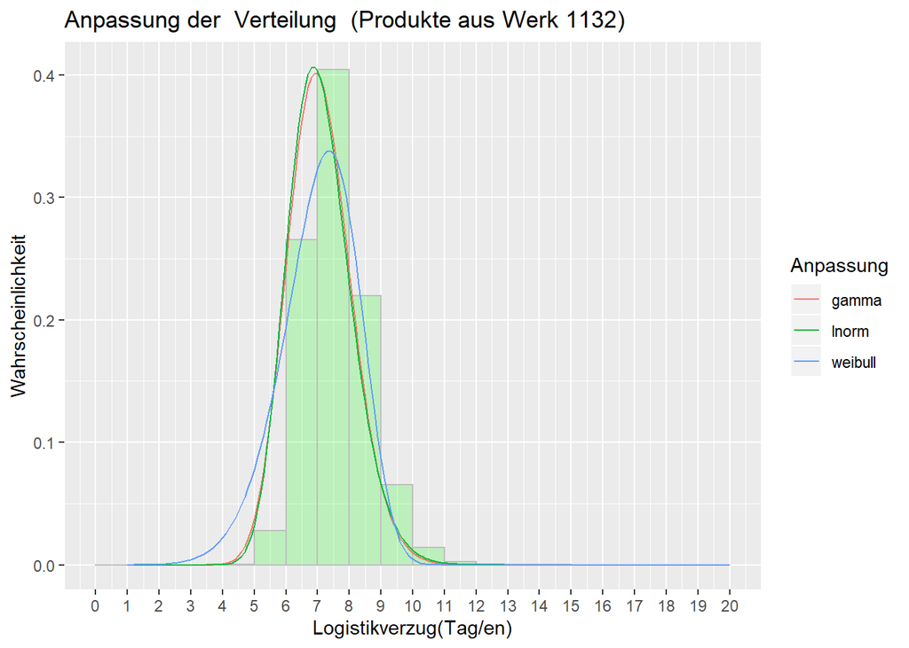

```r
Darstellung_1132
```

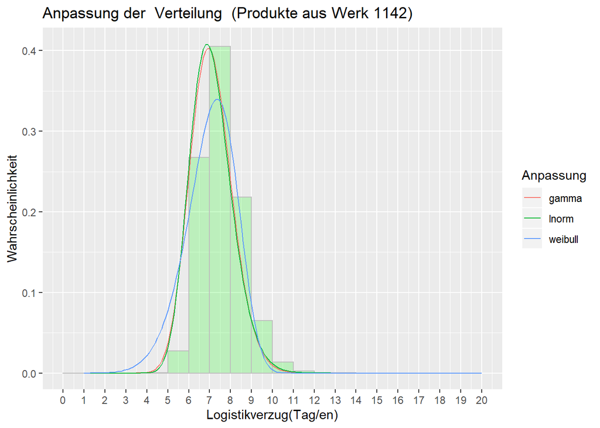

```r
Darstellung_1142
```

code siehe Einschätzung der Parameter für bestimmt Verteilungsmodell

# 3 Aufgabe 2

> Warum ist es sinnvoll, die Ihnen bereitgestellten Daten in separaten Dateien abzulegen und nicht alles in einer riesigen Tabelle abzuspeichern? Wie nennt sich das zugrunde liegende Datenbankkonzept?

Dieses Datenbankkonzept heißt `Relationaler Datenbankansatz`.

Gründe

- **Leistungsfähigkeit**

  Einlesen einer riesigen Tabelle ist Zeitaufwandig. Nur kleiner Teil von Daten in der Tabelle ist für Problemlösen relevant. Aber unrelevante Daten in einer riesigen Tabelle werden trotzdem für Bearbeitung in Arbeitsspeicher(RAM) eingelesen. `Relationaler Datenbankansatz` kann die Leistungsfähigkeit verbessern. Bei `Relationaler Datenbankansatz` ist Datenstruktur einfacher. Man kann gewünschte Daten in einer bestimmte Tabelle finden.
- **Ausfallsicherheit**

  Bei `Relationaler Datenbankansatz` kann die Daten verteilt abgelegt werden. Jeder Server speichert nur einen Teil von gesamter Daten. Fällt ein Server aus, ist nicht der gesamte Datenbestand betroffen.
- **Kosteneffizienz**

  Riesige Datensätze in einer einzige Tabelle erfordert z.B große kapazität von Arbeitsspeicher oder Festplatte.
- **Zuverlässigkeit**

  Bei `Relationaler Datenbankansatz` gibt es noch Verknüpfung (`Primary Key`) zwischen Tabelle. NA-Werte in einer Tabelle könnten eventuell anhand die Beziehung mit anderen Tabellen vervöllständigt oder nachgeprüft werden.

# 4 Aufgabe 3

> Wie viele der Komponenten K7 landeten in Fahrzeugen, die in Köln zugelassen wurden?

7614 der Komponenten K7 landeten in Fahrzeugen, die in Köln zugelassen wurden

Code siehe Code für Aufgabe 3

# 5 Aufgabe 4

> Welche Datentypen haben die Attribute der Zulassungstabelle „Zulassungen_aller_Fahrzeuge“?

```r
str(Zulassungen_alle_Fahrzeuge)
```

```
## Classes 'spec_tbl_df', 'tbl_df', 'tbl' and 'data.frame': 3204104 obs. of  4 variables:
##  $ X1       : num  408097 408098 1 2 3 ...
##  $ IDNummer : chr  "11-1-11-1" "11-1-11-2" "12-1-12-1" "12-1-12-2" ...
##  $ Gemeinden: chr  "DRESDEN" "DRESDEN" "LEIPZIG" "LEIPZIG" ...
##  $ Zulassung: Date, format: "2009-01-01" "2009-01-01" ...
##  - attr(*, "spec")=
##   .. cols(
##   ..   X1 = col_double(),
##   ..   IDNummer = col_character(),
##   ..   Gemeinden = col_character(),
##   ..   Zulassung = col_date(format = "")
##   .. )
```

| Attribute | Datentyp |
| --- | --- |
| `X1` | num –> `numeric` |
| `IDNummer` | chr–> `character` |
| `Gemeinden` | chr–> `character` |
| `Zulassung` | Date–> `Date` |

Code siehe Code für Aufgabe 4

# 6 Aufgabe 5

> Sie wollen Ihre Applikation veröffentlichen. Warum ist es gerade dann sinnvoll die Datensätze auf der Datenbank eines Servers abzulegen? Warum können Sie die Datensätze nicht auf Ihrem persönlichen Computer ablegen? Nennen Sie eine einfache Möglichkeit Ihre Applikation ihrem Kundenkreis zugänglich zu machen?

Gründe: Ein Server wird normalerweise mit statische IPv4-Addresse vergeben. Über Internet sind die Datensätze auf Server immer für jeden Benutzer zugreifbar. Für PC ist die IPv4-Addresse dynamisch vergeben. Die Shiny-App auf deinem PC ist nur den Benutzer in glechem Subnetz sichtbar.

Ein Server ist meistens mehr Leistungsfähig als ein PC. Riesige Anzahl von gleichzeitigem Besuch auf die App wäre lediglich eine relative geringe Belastung für einen Server. Aber PC vielleicht kann hohe Belastung nicht tragen.

Einfache Möglichkeit:

Unser Unternehmen können eine offentliche IPv4-Addresse für eine Computer beantragen. Über diese IPv4-Addresse ist diese Computer von allen Kunden per Internet zugreifbar. Laufen deine Shiny-App an diesem Computer, und deine Kunden mitteilen,auf welche IPv4-Addresse und Portnummer die App veröffentlicht wurde.

# 7 Aufgabe 6

> Am 11.08.2010 hat es einen Unfall mit Fahrerflucht gegeben. Von dem Kennzeichen des Unfallwagens fehlt jede Spur. Die Polizei bittet Sie um Hilfe, da Sie für das Kraftfahrtbundesamt arbeiten und fragt, wo das Fahrzeug mit der Karosseriebauteilnummer „K4-112-1121-23“ zugelassen wurde.

Der Fahzeug wurde in Gemeinde RADEBERG zugelassen.

code siehe Code für Aufgabe 6